# Tick Data Synchronisation

## 1. Previous tick

The previous tick synchronisation procedure saves two time series for each original tick-data:

1. the closing price series
2. the number of ticks between each observation in the original series

The information about volume of each tick were disregarded.

### 1.1. Equally spaced intervals, delta = 1 hour

TU is the time series with the lowest number of observations of all 4 time series.

```r
TU <- read.csv.zoo("../data/TU_prev_tick_hour.csv", header=FALSE,
                   format="%Y-%m-%d %H:%M:%S", tz="GMT",
                   col.names=c("timestamp", "close", "nobs"))
nrow(TU)
```

```
## [1] 219105
```

```r
head(TU)
```

```
##                        close nobs
## 1991-01-02 08:00:00 101.3750    2
## 1991-01-02 09:00:00 101.4219    9
## 1991-01-02 10:00:00 101.4219    0
## 1991-01-02 11:00:00 101.4531    1
## 1991-01-02 12:00:00 101.4844    9
## 1991-01-02 13:00:00 101.5000    2
```

We get equally-spaced observations but we impute a lot of data until the year 2004 and then we discard all of the higher frequency data between 2004 and 2015.

There is a noticable drop of close price in 2000 (this seems to have happened between 1999-11-29 07:00:00 and 1999-11-29 08:00:00). There is also a noticable drop of number of observations in 2015.

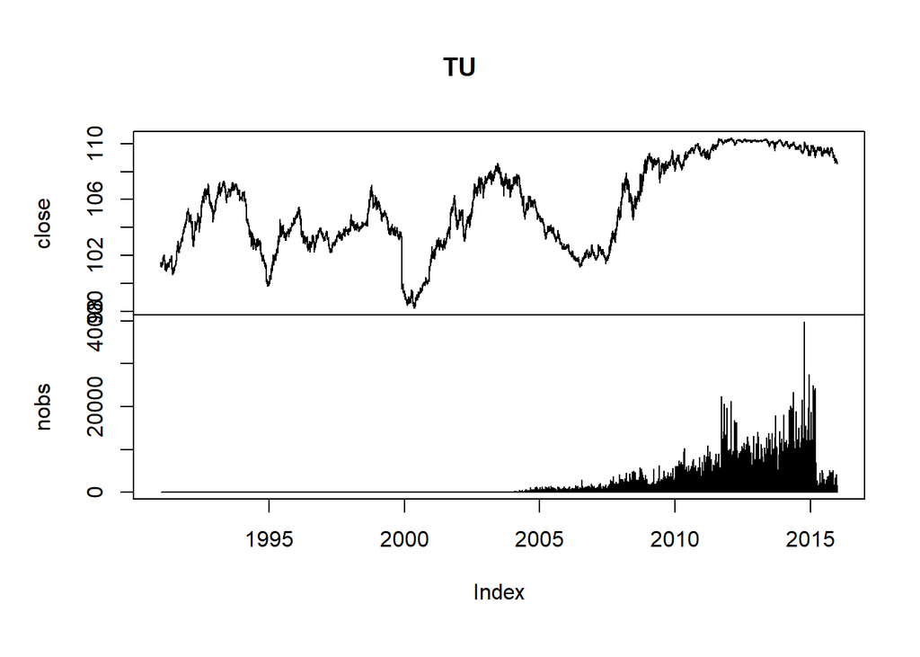

```r
plot(TU)
```

Over 58% of the observations were imputed (127794/219105).

```r
head(table(coredata(TU)[, 2]), n=15L)
```

```
##
##      0      1      2      3      4      5      6      7      8      9
## 127794   3661   2696   2434   2314   2154   2063   1929   1720   1634
##     10     11     12     13     14
##   1467   1257   1240   1135    993
```

In the extreme case, we have used 39742 ticks to create 1 observation.

```r
summary(TU)
```

```
##      Index                         close             nobs
##  Min.   :1991-01-02 08:00:00   Min.   : 98.22   Min.   :    0.0
##  1st Qu.:1997-04-02 16:00:00   1st Qu.:103.21   1st Qu.:    0.0
##  Median :2003-07-03 00:00:00   Median :105.22   Median :    0.0
##  Mean   :2003-07-03 00:00:00   Mean   :105.59   Mean   :  230.4
##  3rd Qu.:2009-10-01 08:00:00   3rd Qu.:108.67   3rd Qu.:   31.0
##  Max.   :2015-12-31 16:00:00   Max.   :110.41   Max.   :39742.0
```

We get similar results when using TY - the tick data time series with the most observations. Same drop of prices in 2000 and same drop in number of observations in 2015. We have imputed 124638 observations and there were maximum of 184919 observations in one synchronisation time interval.

```r
TY <- read.csv.zoo("../data/TY_prev_tick_hour.csv", header=FALSE,
                   format="%Y-%m-%d %H:%M:%S", tz="GMT",
                   col.names=c("timestamp", "close", "nobs"))
nrow(TY)
```

```
## [1] 219105
```

```r
head(TY)
```

```
##                        close nobs
## 1991-01-02 08:00:00 99.09375   36
## 1991-01-02 09:00:00 99.31250   33
## 1991-01-02 10:00:00 99.25000   24
## 1991-01-02 11:00:00 99.28125   17
## 1991-01-02 12:00:00 99.37500   17
## 1991-01-02 13:00:00 99.43750   20
```

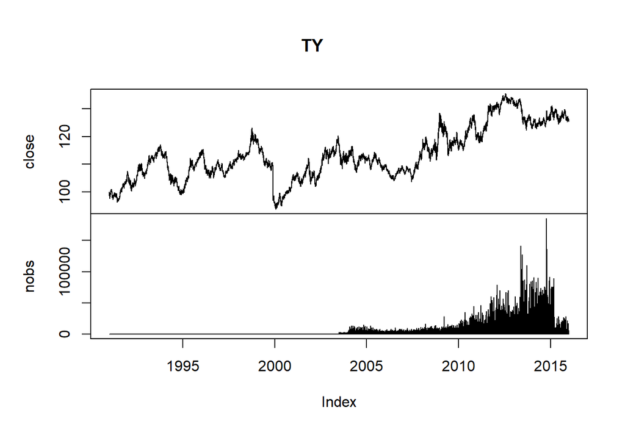

```r
plot(TY)
```

```r
head(table(coredata(TY)[, 2]), n=15L)
```

```
##
##      0      1      2      3      4      5      6      7      8      9
## 124638   1032    624    235     95     95    113    139    160    157
##     10     11     12     13     14
##    221    247    222    265    277
```

```r
summary(TY)
```

```
##      Index                         close            nobs
##  Min.   :1991-01-02 08:00:00   Min.   : 93.7   Min.   :     0
##  1st Qu.:1997-04-02 16:00:00   1st Qu.:107.0   1st Qu.:     0
##  Median :2003-07-03 00:00:00   Median :112.1   Median :     0
##  Mean   :2003-07-03 00:00:00   Mean   :113.5   Mean   :  1039
##  3rd Qu.:2009-10-01 08:00:00   3rd Qu.:119.4   3rd Qu.:   257
##  Max.   :2015-12-31 16:00:00   Max.   :135.5   Max.   :184919
```

### 1.2. Equally spaced intervals, delta = 1 minute

Let us try change the sync interval to one minute using the TU data.

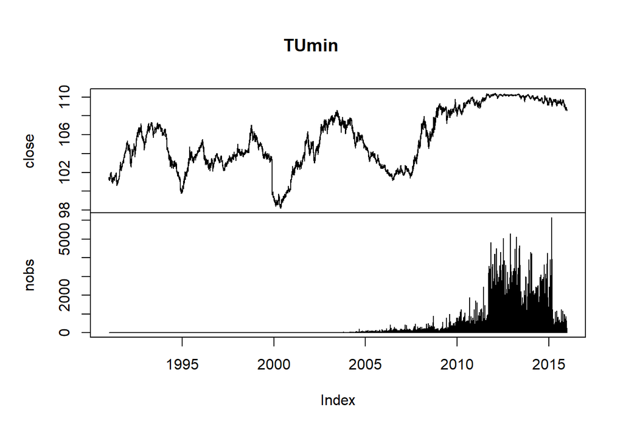

```r
TUmin <- read.csv.zoo("../data/TU_prev_tick_min.csv", header=FALSE,
                   format="%Y-%m-%d %H:%M:%S", tz="GMT",
                   col.names=c("timestamp", "close", "nobs"))
plot(TUmin)
```

```r
head(table(coredata(TUmin)[, 2]), n=15L)
```

```
##
##        0        1        2        3        4        5        6        7
## 10955676   529742   279943   151296   128889    91479    78915    64167
##        8        9       10       11       12       13       14
##    58053    47272    43608    37297    34080    30131    27927
```

```r
summary(TUmin)
```

```
##      Index                         close             nobs
##  Min.   :1991-01-02 07:27:00   Min.   : 98.19   Min.   :   0.00
##  1st Qu.:1997-04-02 15:35:15   1st Qu.:103.21   1st Qu.:   0.00
##  Median :2003-07-02 23:43:30   Median :105.22   Median :   0.00
##  Mean   :2003-07-02 23:43:30   Mean   :105.59   Mean   :   3.84
##  3rd Qu.:2009-10-01 07:51:45   3rd Qu.:108.67   3rd Qu.:   0.00
##  Max.   :2015-12-31 16:00:00   Max.   :110.41   Max.   :6151.00
```

```r
var(TU$close)
```

```
## [1] 9.767028
```

```r
var(TUmin$close)
```

```
## [1] 9.766991
```

The estimate of the minute data’s variance is almost identical to the estimate of the hourly data’s variance.

## 2. Generalised Sampling Time

A synchronisation scheme described by Aït-Sahalia et al.[^1] where we take the shortest period within which all of the time series to be synchronised registered at least one tick. Then we calculate a statistic of the subset of each time series in the given period and thus we obtain one synchronised observation for each time series. If we take the last observation in the subset, we call the synchronisation scheme the refresh time. If we take a random observation from the subset, we refer to it as a generalised sampling time.

### 2.1. Refresh Time

```r
# load and parse timestamps
refreshTime <- fread(file.path("..", "data", "ALL_refresh_time.csv"), header=FALSE)
```

[output not shown]

```r
names(refreshTime) <- c("timestamp", "tu", "fv", "ty", "us")
refreshTime[, timestamp := as.POSIXct(timestamp, format="%Y-%m-%d %H:%M:%OS")]

# summary statistics
nrow(refreshTime)
```

```
## [1] 5996477
```

```r
head(refreshTime)
```

```
##              timestamp       tu       fv       ty       us
## 1: 1991-01-02 07:26:14 101.3594 101.1406 99.09375 96.12500
## 2: 1991-01-02 07:48:54 101.3750 101.1406 99.06250 96.12500
## 3: 1991-01-02 08:11:14 101.4125 101.1875 99.12500 96.21875
## 4: 1991-01-02 08:15:36 101.3969 101.1719 99.09375 96.18750
## 5: 1991-01-02 08:25:24 101.4062 101.1719 99.12500 96.25000
## 6: 1991-01-02 08:28:26 101.3969 101.1875 99.12500 96.25000
```

```r
tail(refreshTime)
```

```
##                  timestamp       tu       fv       ty       us
## 1: 2015-12-31 15:25:55.266 108.6406 118.3594 125.9219 153.4688
## 2: 2015-12-31 15:29:30.016 108.6328 118.3594 125.9219 153.5000
## 3: 2015-12-31 15:39:57.631 108.6328 118.3672 125.9219 153.5000
## 4: 2015-12-31 15:52:39.625 108.6328 118.3516 125.8906 153.4688
## 5: 2015-12-31 15:54:05.842 108.6328 118.3516 125.8906 153.4688
## 6: 2015-12-31 15:59:02.753 108.6328 118.3516 125.8906 153.4375
```

```r
summary(refreshTime)
```

```
##    timestamp                            tu               fv
##  Min.   :1991-01-02 07:26:14.00   Min.   : 98.19   Min.   : 96.53
##  1st Qu.:2008-05-02 08:30:15.00   1st Qu.:106.43   1st Qu.:112.10
##  Median :2010-04-02 08:02:00.00   Median :108.96   Median :117.51
##  Mean   :2010-03-19 04:40:50.13   Mean   :107.87   Mean   :116.10
##  3rd Qu.:2012-11-13 03:00:17.20   3rd Qu.:109.79   3rd Qu.:120.20
##  Max.   :2015-12-31 15:59:02.75   Max.   :110.41   Max.   :125.00
##        ty               us
##  Min.   : 93.75   Min.   : 89.03
##  1st Qu.:114.94   1st Qu.:116.23
##  Median :120.58   Median :122.75
##  Mean   :120.47   Mean   :127.46
##  3rd Qu.:126.64   3rd Qu.:139.06
##  Max.   :135.48   Max.   :166.81
```

```r
# variance
sapply(refreshTime[, 2:5], var)
```

```
##         tu         fv         ty         us
##   6.527376  32.428070  60.030869 211.224077
```

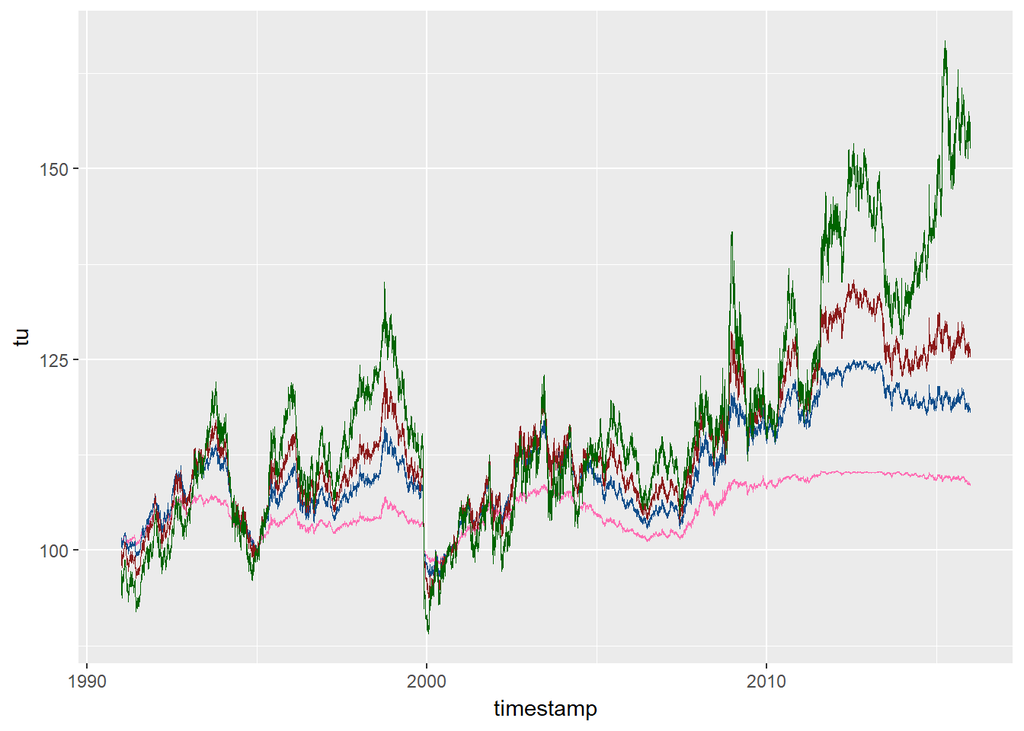

```r
# plot of the series
ggp <- ggplot(data=refreshTime, aes(x=timestamp), alpha=0.75) +
    geom_line(aes(y=tu), size=0.25, colour="hotpink1") +
    geom_line(aes(y=fv), size=0.25, colour="dodgerblue4") +
    geom_line(aes(y=ty), size=0.25, colour="firebrick4") +
    geom_line(aes(y=us), size=0.25, colour="darkgreen")
print(ggp)
```

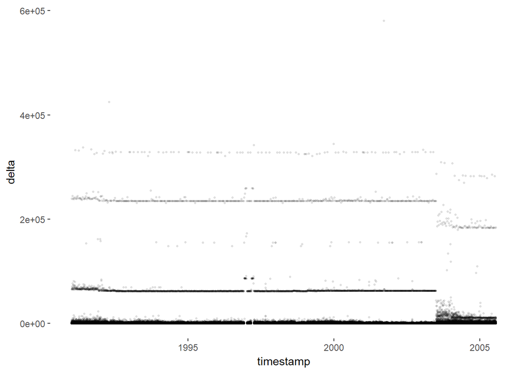

```r
# time difference between two consecutive synchronised observations
refreshTime[, delta := as.numeric(timestamp - shift(timestamp, 1L))]
nobs <- 500000
# first 500000 obs
ggp <- ggplot(data=head(refreshTime, nobs), aes(x=timestamp, y=delta)) +
    geom_point(alpha=0.1, size=0.5) +
    theme(
        panel.grid.major = element_blank(),
        panel.grid.minor = element_blank(),
        panel.background = element_blank()
    )
print(ggp)
```

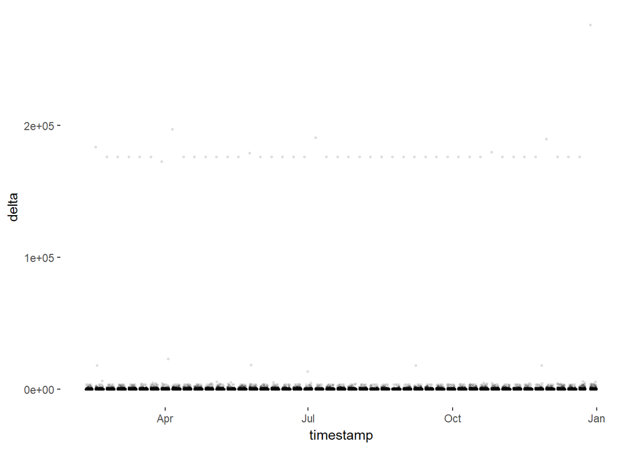

```r
# last 500000 obs
ggp <- ggplot(data=tail(refreshTime, nobs), aes(x=timestamp, y=delta)) +
    geom_point(alpha=0.1, size=0.5) +
    theme(
        panel.grid.major = element_blank(),
        panel.grid.minor = element_blank(),
        panel.background = element_blank()
    )
print(ggp)
```

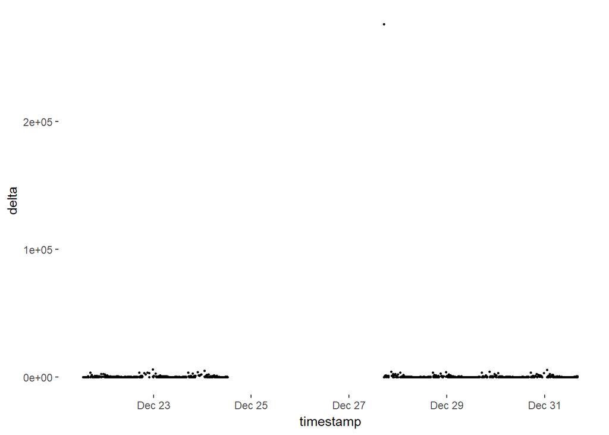

```r
# last 10000 obs
ggp <- ggplot(data=tail(refreshTime, 10000), aes(x=timestamp, y=delta)) +
    geom_point(alpha=1, size=0.5) +
    theme(
        panel.grid.major = element_blank(),
        panel.grid.minor = element_blank(),
        panel.background = element_blank()
    )
print(ggp)
```

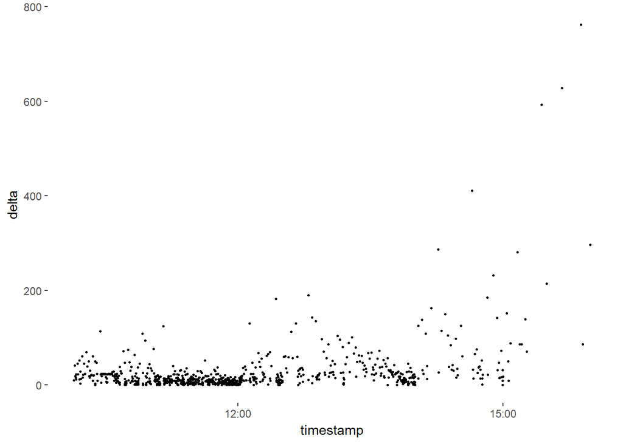

```r
# last 1000 obs
ggp <- ggplot(data=tail(refreshTime, 1000), aes(x=timestamp, y=delta)) +
    geom_point(alpha=1, size=0.5) +
    theme(
        panel.grid.major = element_blank(),
        panel.grid.minor = element_blank(),
        panel.background = element_blank()
    )
print(ggp)
```

## 2.2. Generalised Sampling Time

The data were also synchronised using the generalised sampling time but the exploratory results would be almost identical to the refresh time and thus are omitted.

[^1]: Aït-Sahalia, Y., Fan, J., and Xiu, D. (2010). High- Frequency Covariance Estimates With Noisy and Asynchronous Financial Data. Journal of the American Statistical Association, 105(492):1504–1517.